# Analisis de Mapas Utilizados en Posters

Juan Jara

2024-12-06

# Introduccion

Asistí al Congreso de Agroecología, realizado el 8 de noviembre de 2024 en la Universidad Nacional de Luján. Se dispuso de un area donde se presentaron numerosos pósteres, y, dado que no tuve tiempo suficiente para revisarlos todos, tomé fotografías para analizar la información que más me interesa: los datos georreferenciados de productores agroecológicos.

Mi intención tambien es realizar un póster y, para ello, quise observar cómo estaban diseñados, poniendo especial atención la divulgacion de informacion con el uso de mapas. Por esta razón, mi análisis se centra exclusivamente en los pósteres que incorporaron mapas en su contenido.

# Utilizacion de Mapas

Mi primer analisis, es la proporcion de trabajos que incluyeron por lo menos un mapa en su poster:

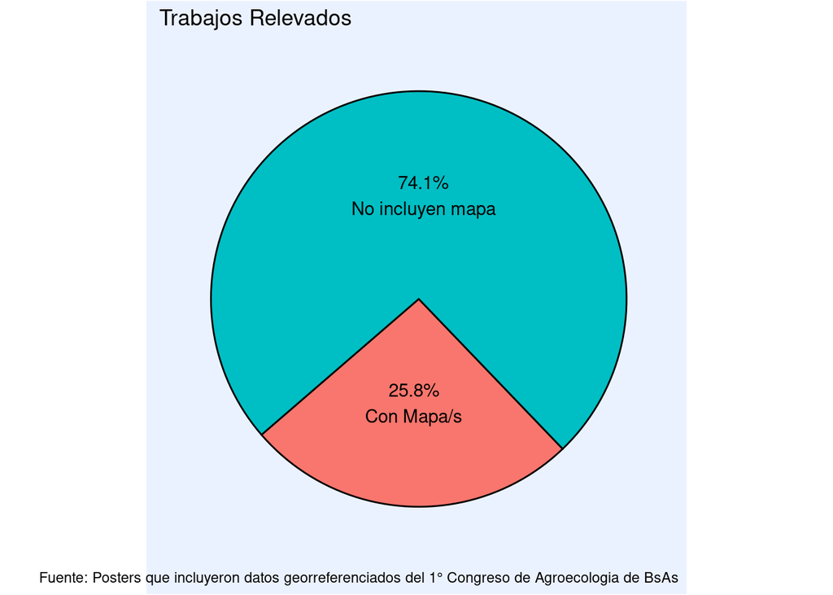

Los que utilizaron un mapa, nos comparten la ubicacion en la que se llevo a cabo el estudio, las ubicaciones donde hay productores agroecologicos, imagenes satelitales para mostrar los alrededores, pero todo no se puede con un solo mapa, por lo que se utilizan varios, cada uno solo con la informacion necesaria a mostrar.

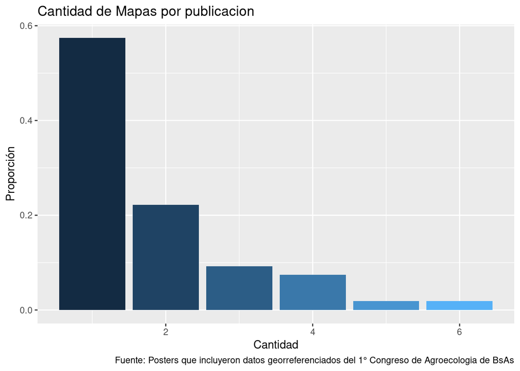

# La Atribucion

La atribución de los datos de un mapa no solo es una cuestión de ética, sino también de responsabilidad y transparencia.

Reconocer la fuente de los datos garantiza la credibilidad de la información y permite a otros usuarios verificar su validez.

Además, es una forma de respetar el trabajo de quienes recolectaron y procesaron esa información, promoviendo una cultura de colaboración y confianza en el uso de datos geoespaciales.

Sin la atribución adecuada, corremos el riesgo de malinterpretar o descontextualizar los datos, lo que puede llevar a decisiones erróneas o a la perpetuación de información incorrecta.

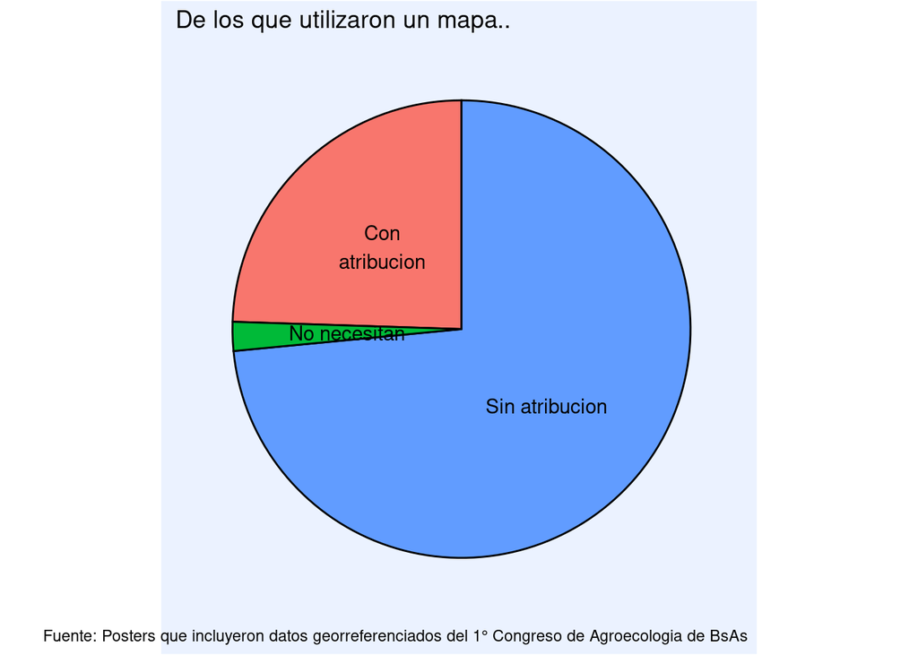

Sin tener la atribucion correspondiente, uno puede dilusidar el mapa es por los elementos que lo componen, como por ejemplo las ciudades trampa (Agloe) , las calles trampa (Calles pavimentadas sobre un rio), o mas reciente, el mapa base utilizado en los navegadores web, aplicaciones y dispositivos gps.

En esto, trate de dilusidar la fuente, pero en algunos, la tranformacion de los datos hace lo imposible, en otros por fuera del mapa incluyen los servicios utilizados.

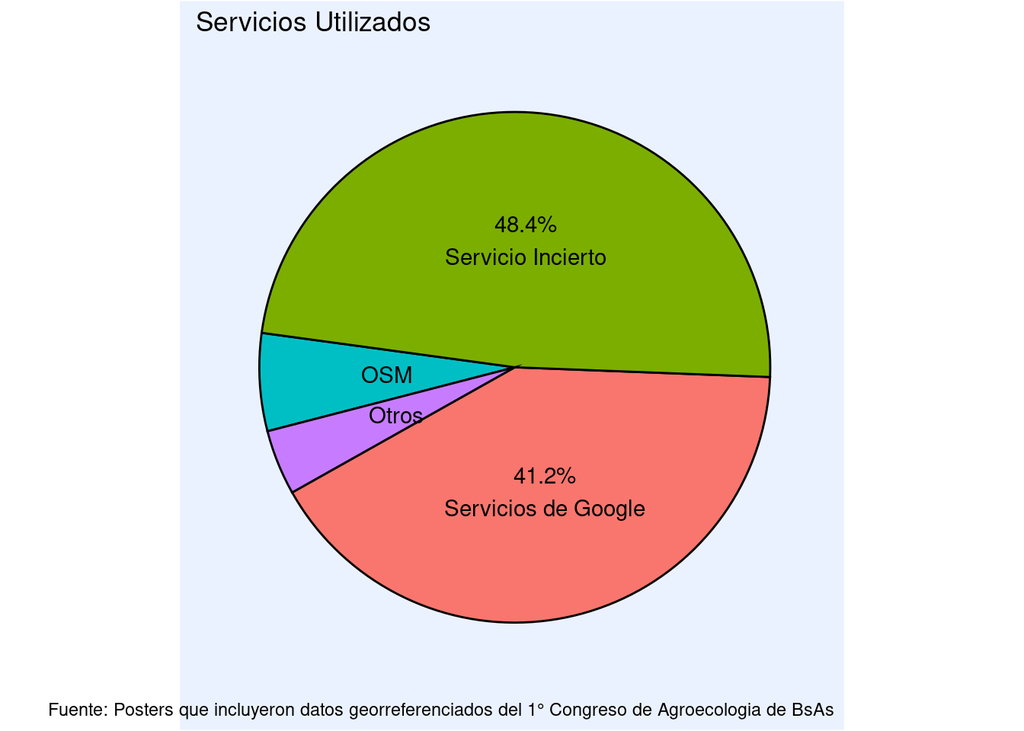